# Practical Machine Learning_Prediction Assignment

MNeisler

October 10, 2016

## Synopsis

The goal of this project is to predict the manner in which participants conducted an exercise, Unilateral Dumbell Biceps Curl, using data from accelerometers on the belt, forearm, arm, and dumbell of 6 participants.

We are using data from a weight lifting excercises study in which participants were asked to perform barbell lifts correctly and incorrectly in 5 different ways: “exactly according to the specification (Class A), throwing the elbows to the front (Class B), lifting the dumbbell only halfway (Class C), lowering the dumbbell only halfway (Class D) and throwing the hips to the front (Class E) (Velloso et al. 2013).” Read more: http://groupware.les.inf.puc-rio.br/har#ixzz4M3W3G2zV

The goal of this assigment is to develop a model that can predict the appropriate activity quality (class A-E) (the “classe” variable in the training set) by processing data gathered from the accelerometers.

This report describes the following:

- Model selection and building
- Cross-validation
- Expected out of sample error
- Rationale for selections

The selected model will be run on the test data to predict the outcome of 20 different test cases.

## Getting and Loading the Data

We first load the required libraries need to run our analysis.

```r
library(caret)
library(randomForest)
library(splines)
library(rpart)
library(rattle)
```

```r
library(rpart.plot)
```

We then load both the training and test data sets. The testing and training data can be found at the following urls:

```r
trainUrl <- "http://d396qusza40orc.cloudfront.net/predmachlearn/pml-training.csv"
testUrl <- "http://d396qusza40orc.cloudfront.net/predmachlearn/pml-testing.csv"
# We import the data treating empty values as NA.
training <- read.csv(url(trainUrl), na.strings=c("", "NA"), header= TRUE)
testing <- read.csv(url(testUrl), na.strings=c("", "NA"), header = TRUE)
```

## Data Preparation

There are a total of 160 variables in the data set. We can reduce the size of the training set by removing all near zero variance variables or variables that contain a large number of NAs to create a new clean training data set.

```r
naSUM <- sapply(training, function(n) sum(length(which(is.na(n)))))
nearVar <- nearZeroVar(training, saveMetrics = TRUE)
table(nearVar$nzv, naSUM)
```

```
##        naSUM
##          0 19216
##   FALSE 59    58
##   TRUE   1    42
```

```r
cleanTraining <- training[,(!nearVar$nzv & naSUM < 19216)]
```

We then remove the first column of the dataset (ID) and other variables that are not measurements so they do not interfere with the algorithm.

```r
cleanTraining <- cleanTraining[, -c(1:6)]
```

The training set has now been reduced to only 53 variables.

We then split the data into a training (70%) and testing (30%) data set, which we will use for cross validation and to assess the out of sample error of the predictor. The data is split by the predictor variable (“classe”).

```r
set.seed(3456)
inTrain <- createDataPartition(y= cleanTraining$classe, p=0.7, list=FALSE)
myTraining <- cleanTraining[inTrain,]
myTesting <- cleanTraining[-inTrain,]

dim(myTraining); dim(myTesting)
```

```
## [1] 13737    53
```

```
## [1] 5885   53
```

## Model Selection and Prediction

We build two different models, decision tree and random forest, on our training set and evaluate them on the test set.

### Decision Tree

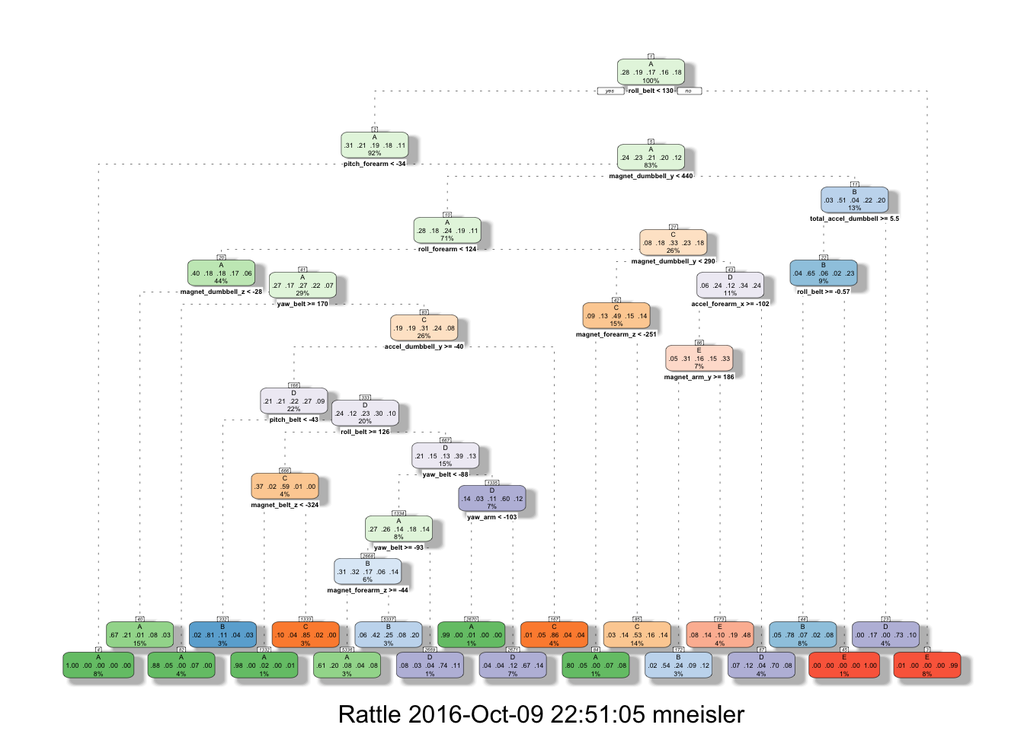

```r
modFit_DT <- rpart(classe ~ ., data = myTraining, method="class")
fancyRpartPlot(modFit_DT)
```

Run the model against the testing data and use a confusion matrix to test the results.

```r
set.seed(5678)

prediction_DT <- predict(modFit_DT, myTesting, type = "class")
confusionMatrix(prediction_DT, myTesting$classe)
```

```
## Confusion Matrix and Statistics
##
##           Reference
## Prediction    A    B    C    D    E
##          A 1500  238   16   85   49
##          B   49  647  119   46  111
##          C   59  130  795  132  137
##          D   43   84   66  664  104
##          E   23   40   30   37  681
##
## Overall Statistics
##
##                Accuracy : 0.7285
##                  95% CI : (0.7169, 0.7398)
##     No Information Rate : 0.2845
##     P-Value [Acc > NIR] : < 2.2e-16
##
##                   Kappa : 0.6552
##  Mcnemar's Test P-Value : < 2.2e-16
##
## Statistics by Class:
##
##                      Class: A Class: B Class: C Class: D Class: E
## Sensitivity            0.8961   0.5680   0.7749   0.6888   0.6294
## Specificity            0.9079   0.9315   0.9057   0.9396   0.9729
## Pos Pred Value         0.7945   0.6656   0.6345   0.6909   0.8397
## Neg Pred Value         0.9565   0.8999   0.9501   0.9391   0.9210
## Prevalence             0.2845   0.1935   0.1743   0.1638   0.1839
## Detection Rate         0.2549   0.1099   0.1351   0.1128   0.1157
## Detection Prevalence   0.3208   0.1652   0.2129   0.1633   0.1378
## Balanced Accuracy      0.9020   0.7498   0.8403   0.8142   0.8012
```

### Random Forest Model

We then try prediction with the random forest model.

```r
set.seed(5678)
modFit_RF <- randomForest(classe ~ ., data = myTraining, ntree = 1000)
prediction_RF <- predict(modFit_RF, myTesting, type = "class")
confusionMatrix(prediction_RF, myTesting$classe)
```

```
## Confusion Matrix and Statistics
##
##           Reference
## Prediction    A    B    C    D    E
##          A 1674    7    0    0    0
##          B    0 1132    1    0    0
##          C    0    0 1020   11    1
##          D    0    0    5  953    3
##          E    0    0    0    0 1078
##
## Overall Statistics
##
##                Accuracy : 0.9952
##                  95% CI : (0.9931, 0.9968)
##     No Information Rate : 0.2845
##     P-Value [Acc > NIR] : < 2.2e-16
##
##                   Kappa : 0.994
##  Mcnemar's Test P-Value : NA
##
## Statistics by Class:
##
##                      Class: A Class: B Class: C Class: D Class: E
## Sensitivity            1.0000   0.9939   0.9942   0.9886   0.9963
## Specificity            0.9983   0.9998   0.9975   0.9984   1.0000
## Pos Pred Value         0.9958   0.9991   0.9884   0.9917   1.0000
## Neg Pred Value         1.0000   0.9985   0.9988   0.9978   0.9992
## Prevalence             0.2845   0.1935   0.1743   0.1638   0.1839
## Detection Rate         0.2845   0.1924   0.1733   0.1619   0.1832
## Detection Prevalence   0.2856   0.1925   0.1754   0.1633   0.1832
## Balanced Accuracy      0.9992   0.9968   0.9958   0.9935   0.9982
```

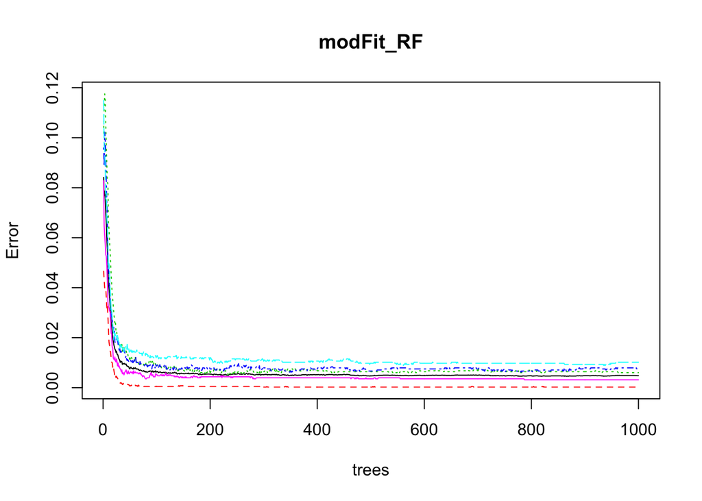

The random forest model has an accuracy of 99.52% when applied to the testing data set and higher compared to the accuracy of the decision tree model, only 72.8%.

## Out of Sample Error Comparison

```r
dt_outofsample = (confusionMatrix(prediction_DT, myTesting$classe))$overall[1]
rf_outofsample = (confusionMatrix(prediction_RF, myTesting$classe))$overall[1]
```

```r
out.of.sample.errors = c(as.numeric(1-dt_outofsample),
                         as.numeric(1-rf_outofsample))
names(out.of.sample.errors) = c("DT","RF")
out.of.sample.errors
```

```
##          DT          RF
## 0.271537808 0.004757859
```

The random forest model also has a lower out of sample error of only 0.48%.

## Final Test and Conclusion

Since the Random Forest model had a higer accuracy and lower out of sample error rate compared to the decision tree, we will apply the Random Forest model on the original testing dataset from the website. The model accurately predicted all of the 20 test subjects.

```r
prediction_RFfinal <- predict(modFit_RF, testing, type = "class")
prediction_RFfinal
```

```
##  1  2  3  4  5  6  7  8  9 10 11 12 13 14 15 16 17 18 19 20
##  B  A  B  A  A  E  D  B  A  A  B  C  B  A  E  E  A  B  B  B
## Levels: A B C D E
```

## References

Velloso, E.; Bulling, A.; Gellersen, H.; Ugulino, W.; Fuks, H. Qualitative Activity Recognition of Weight Lifting Exercises. Proceedings of 4th International Conference in Cooperation with SIGCHI (Augmented Human ’13) . Stuttgart, Germany: ACM SIGCHI, 2013.